# Bioconductor Tutorial

http://mrccsc.github.io/r_course/Bioconductor_Tutorial.html  
Tom Carroll, Sanjay Khadayate, Gopuraja Dharmalingam

### Overview

- Introduction to Bioconductor
- GenomicRanges
- Reading Sequence alignemnts
- Annotations
- Exercises

### Bioconductor

Bioconductor (BioC) is an open source, open development software project to provide tools for the analysis and comprehension of high-throughput genomics data

- Started in 2001
- Gained popularity through microarray analysis packages
- Colloborative effort by developers across the world
- Distributed as R packages
- Two releases every year

### Objectives

- Provide access to powerful statistical and graphical methods for analysing genomics data.
- Facilitate retrieval and integration of annotation data (GenBank, GO, Entrez Gene, PubMed).
- Allow the rapid development of extensible, interoperable, and scalable software.
- Promote high-quality documentation and reproducible research.
- Provide training in computational and statistical methods.

### www.bioconductor.org

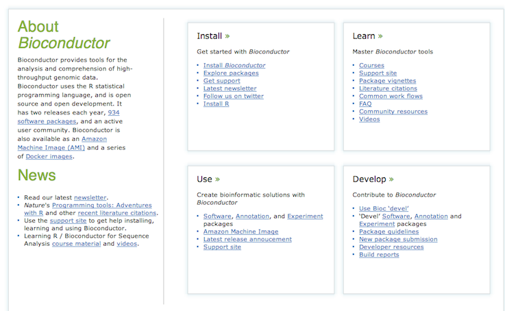

### Bioconductor Release 3.0

- Software (934)
  - Provides implementation of analysis methods
- AnnotationData (870)
  - mapping between microarray probe, gene, pathway, gene ontology, homology and other annotations
  - Representations of GO, KEGG and other annotations, and can easily access NCBI, Biomart, UCSC and other sources
- ExperimentData (219)
  - code, data and documentation for specific experiments or projects

### Installating BioC Packages

Installing & Using a package:

```r
source("http://bioconductor.org/biocLite.R")
biocLite("GenomicRanges")
library("GenomicRanges")
```

### BioC packages for Sequencing Data Analysis

- **Data structures**: IRanges, GenomicRanges, Biostrings, BSgenome
- **Input/Ouput**: ShortRead, Rsamtools, GenomicAlignments and rtracklayer (GTF,GFF,BED)
- **Annotation**: GenomicFeatures, BSgenome, biomaRt, TxDb.*, org.*
- **Alignment**: Rsubread, Biostrings
- **Accessing Database**: SRAdb & GEOquery
- **ChIP-seq peak identification, motif discovery and annotation**: ChIPQC, chipseq, ChIPseqR, ChIPpeakAnno, DiffBind, rGADEM, BayesPeak, MotifDb, SeqLogo.
- **RNA-seq and Differential expression analysis**: Rsubread, GenomicAlignments, edgeR, DESeq2, DEXseq, goseq
- **SNP**: snpStats, SeqVarTools, GGtools
- **Work-flows**: ReportingTools, easyRNASeq, ArrayExpressHTS, oneChannelGUI

### Finding Help

- ?function

```r
library("limma")
?lmFit
```

- Browse Vignettes browseVignettes(package=“limma”)
- Bioconductor Course Materials: http://www.bioconductor.org/help/course-materials/
- Bioconductor mailing list - https://support.bioconductor.org/

## GenomicRanges

### GenomicRanges

- Genomic Ranges provides data structure for efficiently storing genomic coordinates
  - Collection of genes coordinates
  - Transcription factor binding sites (ChIP-Seq peaks)
  - Collection of aligned sequencing reads
- Builds on top of Interval Ranges (IRanges) package and lays foundation for sequencing analysis.
- IRanges are collection of integer interval and GenomicRanges extends IRanges by including chromosome and strand.
- Provides collection of functions for accessing and manipulating Genomic coordinates
- Use cases: Identifying TF binding overlap, counting sequencing reads overlap with a gene
- Main classes: GRanges and GRangesList

### Run Length Encoding (Rle)

- Run length encoding is a data compression technique
- Efficiently encoding the redundant information

```r
# Orginial vector
# chr1, chr2, chr2, chr2, chr1, chr1, chr3, chr3

library(GenomicRanges)
chr <- Rle(c("chr1", "chr2", "chr1", "chr3"), c(1, 3, 2, 2))
chr
```

```
character-Rle of length 8 with 4 runs
  Lengths:      1      3      2      2
  Values : "chr1" "chr2" "chr1" "chr3"
```

The above Rle can be interpreted as a run of length 1 of chr1, followed by run length of 3 of chr2, followed by run length of 2 of chr1 and followed by run length of 2 of chr3

### Constructing GRanges object

GRanges class represents a collection of genomic features with single start and end location on the genome. GRanges object can be cretated using **GRanges** function.

```r
library("GenomicRanges")
gr1 <- GRanges(seqnames = Rle(c("chr1", "chr2", "chr1", "chr3"), c(1, 3, 2, 4)),
               ranges = IRanges(start=11:20, end = 50:59, names = head(letters,10)),
               strand = Rle(c("-", "+", "-", "+", "-"), c(1,2, 2, 3, 2)),
               score = 1:10, GC = runif(10,0,1))
gr1
```

```
GRanges with 10 ranges and 2 metadata columns:
    seqnames    ranges strand |     score                 GC
       <Rle> <IRanges>  <Rle> | <integer>          <numeric>
  a     chr1  [11, 50]      - |         1  0.778777468018234
  b     chr2  [12, 51]      + |         2  0.697875699028373
  c     chr2  [13, 52]      + |         3  0.684974947245792
  d     chr2  [14, 53]      - |         4 0.0643513759132475
  e     chr1  [15, 54]      - |         5 0.0453450796194375
  f     chr1  [16, 55]      + |         6  0.346536554628983
  g     chr3  [17, 56]      + |         7    0.3067692425102
  h     chr3  [18, 57]      + |         8  0.996727875666693
  i     chr3  [19, 58]      - |         9 0.0923446526285261
  j     chr3  [20, 59]      - |        10  0.262419407023117
  ---
  seqlengths:
   chr1 chr2 chr3
     NA   NA   NA
```

### Constructing GRanges object

- The coordinates in GRanges are 1-based and left-most (start of a read will always be left-most coordinate of the read regardless of which strand the read aligned to).
- Additional data stored beyond genomic coordinates (separated by “|”) are called metadata. In our case metadata column contains score and GC content.
- Metadata columns are optional and can be extracted from GRanges object using **mcols** function.

```r
mcols(gr1)
```

```
DataFrame with 10 rows and 2 columns
       score         GC
   <integer>  <numeric>
1          1 0.77877747
2          2 0.69787570
3          3 0.68497495
4          4 0.06435138
5          5 0.04534508
6          6 0.34653655
7          7 0.30676924
8          8 0.99672788
9          9 0.09234465
10        10 0.26241941
```

### Constructing GRanges object from data frame

```r
mm9genes <- read.table("mm9Genes.txt",sep="\t",header=T)
head(mm9genes)
```

```
    chr     start       end strand                ens        Symbol
1  chr9 105729415 105731415      - ENSMUSG00000043719        Col6a6
2 chr18  43636450  43638450      - ENSMUSG00000043424        Gm9781
3  chr7  70356455  70358455      - ENSMUSG00000030525        Chrna7
4  chrX 100818093 100820093      - ENSMUSG00000086370 B230206F22Rik
5 chr12  82881157  82883157      - ENSMUSG00000042724        Map3k9
6  chr7 152124774 152126774      - ENSMUSG00000070348         Ccnd1
```

```r
mm9genes.GR <- GRanges(seqnames=mm9genes$chr,
                       ranges=IRanges(start=mm9genes$start,end=mm9genes$end),
                       strand=mm9genes$strand,
                       ENSID=mm9genes$ens,
                       Symbol=mm9genes$Symbol)
```

Another option: **makeGRangesFromDataFrame()**

Converting GRanges object to data frame: **as.data.frame(GRanges)**

### Constructing GRanges object from data frame

```r
head(mm9genes.GR)
```

```
GRanges with 6 ranges and 2 metadata columns:
      seqnames                 ranges strand |              ENSID
         <Rle>              <IRanges>  <Rle> |           <factor>
  [1]     chr9 [105729415, 105731415]      - | ENSMUSG00000043719
  [2]    chr18 [ 43636450,  43638450]      - | ENSMUSG00000043424
  [3]     chr7 [ 70356455,  70358455]      - | ENSMUSG00000030525
  [4]     chrX [100818093, 100820093]      - | ENSMUSG00000086370
  [5]    chr12 [ 82881157,  82883157]      - | ENSMUSG00000042724
  [6]     chr7 [152124774, 152126774]      - | ENSMUSG00000070348
             Symbol
           <factor>
  [1]        Col6a6
  [2]        Gm9781
  [3]        Chrna7
  [4] B230206F22Rik
  [5]        Map3k9
  [6]         Ccnd1
  ---
  seqlengths:
    chr1 chr10 chr11 chr12 chr13 chr14 ...  chr7  chr8  chr9  chrM  chrX
      NA    NA    NA    NA    NA    NA ...    NA    NA    NA    NA    NA
```

### GenomicRangesList

- To represent hierarchical structured data, ex: Exons in a transcript
- List-like data structure
- Each element of the list is GRanges instance

```r
gr2 <- GRanges(seqnames = Rle(c("chr1", "chr3","chr2", "chr1", "chr3"), c(1, 2,1, 2, 4)),
                ranges = IRanges(start=55:64, end = 94:103, names = letters[11:20]),
                strand = Rle(c("+", "-", "+", "-"), c(1, 4, 3, 2)),
                score = 1:10, GC = runif(10,0,1))

GRL <- GRangesList("Peak1" = gr1, "Peak2" = gr2)
```

### Operations on GenomicRanges

**Accessors:** seqnames, start, end, ranges, strand, width, names, mcols, length

**Extraction:** GR[i], GRL[[i]], head, tail

**Set operations:** reduce, disjoin

**Overlaps:** findOverlaps, subsetByOverlaps, countOverlaps, nearest, precede, follow

**Arithmetic:** shift, resize, distance, distanceToNearest

### Operations on GenomicRanges

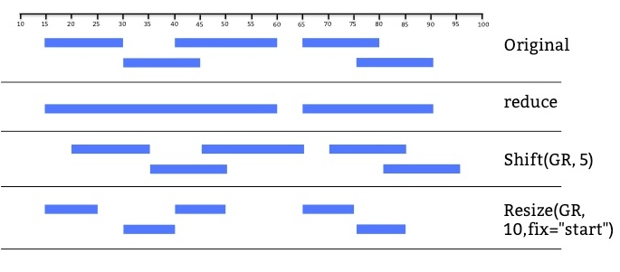

### Operations on GenomicRanges

```r
head(ranges(gr1))
```

```
IRanges of length 6
    start end width names
[1]    11  50    40     a
[2]    12  51    40     b
[3]    13  52    40     c
[4]    14  53    40     d
[5]    15  54    40     e
[6]    16  55    40     f
```

```r
start(gr1)
```

```
 [1] 11 12 13 14 15 16 17 18 19 20
```

```r
width(gr1)
```

```
 [1] 40 40 40 40 40 40 40 40 40 40
```

### Operations on GenomicRanges

Subsetting GRanges

```r
gr1[seqnames(gr1)=="chr1"]
```

```
GRanges with 3 ranges and 2 metadata columns:
    seqnames    ranges strand |     score                 GC
       <Rle> <IRanges>  <Rle> | <integer>          <numeric>
  a     chr1  [11, 50]      - |         1  0.778777468018234
  e     chr1  [15, 54]      - |         5 0.0453450796194375
  f     chr1  [16, 55]      + |         6  0.346536554628983
  ---
  seqlengths:
   chr1 chr2 chr3
     NA   NA   NA
```

Merge overlapping genomic ranges within the same GRanges object

```r
reduce(gr1)
```

```
GRanges with 6 ranges and 0 metadata columns:
      seqnames    ranges strand
         <Rle> <IRanges>  <Rle>
  [1]     chr1  [16, 55]      +
  [2]     chr1  [11, 54]      -
  [3]     chr2  [12, 52]      +
  [4]     chr2  [14, 53]      -
  [5]     chr3  [17, 57]      +
  [6]     chr3  [19, 59]      -
  ---
  seqlengths:
   chr1 chr2 chr3
     NA   NA   NA
```

### Finding overlapping regions

- One of the common tasks in sequencing data analysis
- Ex: Identifying transcription factor binding sites overlap with promoters
- **findOverlaps** function finds intervals overlap between two GRanges object.
- Usage: **function(query,subject)**

```r
gr1_overlaps <- findOverlaps(gr1,gr2,ignore.strand=F)
gr1_overlaps
```

```
Hits of length 5
queryLength: 10
subjectLength: 10
  queryHits subjectHits
   <integer>   <integer>
 1         6           1
 2         9           2
 3         9           3
 4        10           2
 5        10           3
```

Output of findOverlaps is a 'Hits' object indicating which of the query and subject intervals overlap.

### Finding overlapping regions

Convert the 'Hits' object to 2 column matrix using **as.matrix()**. Values in the first column are indices of the query and values in second column are indices of the subject.

```r
gr1_overlaps.m <- as.matrix(gr1_overlaps)
gr1[gr1_overlaps.m[,"queryHits"], ]
```

```
GRanges with 5 ranges and 2 metadata columns:
    seqnames    ranges strand |     score                 GC
       <Rle> <IRanges>  <Rle> | <integer>          <numeric>
  f     chr1  [16, 55]      + |         6  0.346536554628983
  i     chr3  [19, 58]      - |         9 0.0923446526285261
  i     chr3  [19, 58]      - |         9 0.0923446526285261
  j     chr3  [20, 59]      - |        10  0.262419407023117
  j     chr3  [20, 59]      - |        10  0.262419407023117
  ---
  seqlengths:
   chr1 chr2 chr3
     NA   NA   NA
```

### Finding overlapping regions

**subsetByOverlaps** extracts the query intervals overlap with subject intervals

```r
subsetByOverlaps(gr1,gr2,ignore.strand=F)
```

```
GRanges with 3 ranges and 2 metadata columns:
    seqnames    ranges strand |     score                 GC
       <Rle> <IRanges>  <Rle> | <integer>          <numeric>
  f     chr1  [16, 55]      + |         6  0.346536554628983
  i     chr3  [19, 58]      - |         9 0.0923446526285261
  j     chr3  [20, 59]      - |        10  0.262419407023117
  ---
  seqlengths:
   chr1 chr2 chr3
     NA   NA   NA
```

### Finding overlapping regions

Other interesting functions: **nearest()** and **distanceToNearest()**

```r
distanceToNearest(gr1,gr2,ignore.strand=F)
```

```
Hits of length 10
queryLength: 10
subjectLength: 10
   queryHits subjectHits  distance
    <integer>   <integer> <integer>
 1          1           5         8
 2          2          NA        NA
 3          3          NA        NA
 4          4           4         4
 5          5           5         4
 6          6           1         0
 7          7           7         4
 8          8           7         3
 9          9           3         0
 10        10           3         0
```

### Counting overlapping regions

**countOverlaps()** tabulates number of subject intervals overlap with each interval in query, ex: counting number of sequencing reads overlap with genes in RNA-Seq

```r
countOverlaps(gr1,gr2,ignore.strand=T) # note the strand!
```

```
a b c d e f g h i j
0 0 0 0 0 1 1 2 2 2
```

### Computing Coverage

**coverage** calculates how many ranges overlap with individual positions in the genome. **coverage** function returns the coverage as Rle instance.

```r
coverage(gr1)
```

```
RleList of length 3
$chr1
integer-Rle of length 55 with 6 runs
  Lengths: 10  4  1 35  4  1
  Values :  0  1  2  3  2  1

$chr2
integer-Rle of length 53 with 6 runs
  Lengths: 11  1  1 38  1  1
  Values :  0  1  2  3  2  1

$chr3
integer-Rle of length 59 with 8 runs
  Lengths: 16  1  1  1 37  1  1  1
  Values :  0  1  2  3  4  3  2  1
```

## Reading Sequence Alignments

### File formats in NGS

- FASTQ (Fasta with quality)
- SAM/BAM - Sequence Alignment/Map format
- BED
- Wiggle/bedgraph

**FASTQ**

```r
@ERR590398.1 HWI-ST1146:148:C2FVTACXX:8:1101:1172:2059
NAAAATGCATATTCCTAGCATACTTCCCAAACATACTGAATTATAATCTC
+ERR590398.1 HWI-ST1146:148:C2FVTACXX:8:1101:1172:2059
A1BDFFFFHHHHHJJJJJJJJJJJJJJJJJJJJJJJJJJJJJJJJJJIJJ
```

### BAM/SAM

BAM/SAM consist two sections: Header and Alignment

Header section:

Meta data (reference genome, aligner), starts with “@”

### BAM/SAM

Alignment section:

**QNAME:** ID of the read (“query”)  
**FLAG:** alignment flags  
**RNAME:** ID of the reference (typically: chromosome name)  
**POS:** Position in reference (1-based, left side)  
**MAPQ:** Mapping quality (as Phred score)  
**CIGAR:** Alignment description (mismatch, gaps etc.)  
**RNEXT:** Mate/next read reference sequence name  
**MPOS:** Mate/next read position  
**TLEN:** observed Template Length  
**SEQ:** sequence of the read  
**QUAL:** quality string of the read

### Reading Sequence alignments (BAM/SAM)

Methods for reading BAM/SAM

- **readAligned** from ShortRead package – Accept multiple formats – BAM, export
  - Reads all files in a directory
  - Reads base call qualities, chromosome, position, and strand
- **scanBam** from Rsamtools package
  - scanBam reads BAM files into list structure
  - Options to select what fields and which records to import using **ScanBamParam**
- **readGAlignments** from GenomicAlignments package

### Reading Sequence alignments (BAM/SAM)

```r
library("Rsamtools")
BamFile <- system.file("extdata", "ex1.bam", package="Rsamtools")
which <- RangesList(seq1=IRanges(1000, 2000),seq2=IRanges(c(100, 1000), c(1000, 2000)))
what <- c("rname", "strand", "pos", "qwidth", "seq")
param <- ScanBamParam(which=which, what=what)
bamReads <-  scanBam(BamFile, param=param)

length(bamReads) # Each element of the list corresponds to a range speciﬁed by the which argument in ScanBamParam
```

```
[1] 3
```

```r
names(bamReads[[1]]) # elements speciﬁed by the what and tag arguments to ScanBamParam
```

```
[1] "rname"  "strand" "pos"    "qwidth" "seq"
```

### Reading Sequence alignments (BAM/SAM)

**ScanBamParam:**

```r
# Constructor
ScanBamParam(flag = scanBamFlag(), what = character(0), which)

# Constructor helpers
scanBamFlag(isPaired = NA, isProperPair = NA, isUnmappedQuery = NA,
    hasUnmappedMate = NA, isMinusStrand = NA, isMateMinusStrand = NA,
    isFirstMateRead = NA, isSecondMateRead = NA, isNotPrimaryRead = NA,
    isNotPassingQualityControls = NA, isDuplicate = NA)
```

### Reading Sequence alignments (BAM/SAM)

- GenomicRanges package defines the GAlignments class – a specialised class for storing set of genomic alignments (ex: sequencing data)
- Only BAM support now – future version may include other formats
- The readGAlignments function takes an additional argument, **param** allowing the user to customise which genomic regions and which fields to read from BAM -**param** can be constructed using ScanBamParam function

```r
library(GenomicAlignments)
SampleAlign <- readGAlignments(BamFile)
```

### Reading Sequence alignments (BAM/SAM)

We can also customise which regions to read

```r
region <- RangesList(seq1=IRanges(1000, 2000),seq2=IRanges(1000, 2000))
param1 <- ScanBamParam(what=c("rname", "pos", "cigar","qwidth"),which=region)
SampleAlign1 <- readGAlignments(BamFile,param=param1)
```

## Annotation Packages

### BioC Annotation Packages

Annotation packages can be broadly classified in to gene-centric and genome-centric.

**Gene-centric annotation packages (AnnotationDbi):**

- Organism level packages: contains gene annotation for entire organism. Follows “org.XX.YY.db” pattern (Ex: org.Hs.eg.db)
- General System biology data: KEGG.db (association between pathways and genes), GO.db (Gene ontology term and genes) and ReactomeDb
- Platform level packages: Annotation for a specific platform (ex: hgu133a.db for Affymetrix HGU133A microarray).

### BioC Annotation Packages

**Genomic-centric GenomicFeatures packages:**

- TranscriptDB (TxDB) packages contains genomic coordiantes for transcripts specific to a genome build, ex: TxDb.Hsapiens.UCSC.hg19.knownGene. These packages allow access to various features on transcriptome, including exons, genes and transcripts coordinates

**Web-based annotation services:**

- biomaRt provides interface to query web-based biomart' resource for genes, sequence, SNPs, and etc.

### AnnotationDbi Accessor Functions

- **columns** What kind of annotation available in AnnotationDb object.
- **keytypes** Displays which type of identifiers can be passed in to **select** function.
- **keys** returns keys (index) for the database contained in the AnnotationDb object. Used along with **keytypes** in **select** function to retrieve interested annotation
- **select** will retrieve the annotation data as a data.frame based on the supplied keys, keytypes and columns.

**Note:** Package name = Annotation object

We will explore how to retrieve annotation from gene-centric organism level annotation package (org.Hs.eg.db)

### Accessing annotation from org.Hs.eg.db

Load the package and list the contents

```r
library("org.Hs.eg.db")
```

```r
columns(org.Hs.eg.db)
 [1] "ENTREZID"     "PFAM"         "IPI"          "PROSITE"
 [5] "ACCNUM"       "ALIAS"        "CHR"          "CHRLOC"
 [9] "CHRLOCEND"    "ENZYME"       "MAP"          "PATH"
[13] "PMID"         "REFSEQ"       "SYMBOL"       "UNIGENE"
[17] "ENSEMBL"      "ENSEMBLPROT"  "ENSEMBLTRANS" "GENENAME"
[21] "UNIPROT"      "GO"           "EVIDENCE"     "ONTOLOGY"
[25] "GOALL"        "EVIDENCEALL"  "ONTOLOGYALL"  "OMIM"
[29] "UCSCKG"
```

To know more about the above identifier types

```r
help(SYMBOL)
```

### Accessing annotation from org.Hs.eg.db

Which keytypes can be used to query this database? **keytypes** (What is the difference between **columns** and **keytypes**?)

```r
keytypes(org.Hs.eg.db)
 [1] "ENTREZID"     "PFAM"         "IPI"          "PROSITE"
 [5] "ACCNUM"       "ALIAS"        "CHR"          "CHRLOC"
 [9] "CHRLOCEND"    "ENZYME"       "MAP"          "PATH"
[13] "PMID"         "REFSEQ"       "SYMBOL"       "UNIGENE"
[17] "ENSEMBL"      "ENSEMBLPROT"  "ENSEMBLTRANS" "GENENAME"
[21] "UNIPROT"      "GO"           "EVIDENCE"     "ONTOLOGY"
[25] "GOALL"        "EVIDENCEALL"  "ONTOLOGYALL"  "OMIM"
[29] "UCSCKG"
```

### Accessing annotation from org.Hs.eg.db

If we want to extract few identifiers of a particular keytype, we can use **keys** function

```r
head(keys(org.Hs.eg.db, keytype="SYMBOL"))
[1] "A1BG"  "A2M"   "A2MP1" "NAT1"  "NAT2"  "NATP"
```

We can extract other annotations for a particular identifier using **select** function

```r
select(org.Hs.eg.db, keys = "A1BG", keytype = "SYMBOL", columns = c("SYMBOL", "GENENAME", "CHR") )
  SYMBOL               GENENAME CHR
1   A1BG alpha-1-B glycoprotein  19
```

### Annotating results - Example

How can we annotate our results (ex: RNA-Seq differential expression analysis results)?

First, we will load an example results:

```r
load(system.file("extdata", "resultTable.Rda", package="AnnotationDbi"))
head(resultTable)
             logConc     logFC LR.statistic       PValue          FDR
100418920  -9.639471 -4.679498     378.0732 3.269307e-84 2.613484e-80
100419779 -10.638865 -4.264830     291.1028 2.859424e-65 1.142912e-61
100271867 -11.448981 -4.009603     222.3653 2.757135e-50 7.346846e-47
100287169 -11.026699 -3.486593     206.7771 6.934967e-47 1.385953e-43
100287735 -11.036862  3.064980     204.1235 2.630432e-46 4.205535e-43
100421986 -12.276297 -4.695736     190.5368 2.427556e-43 3.234314e-40
```

Rownames of the above dataframe are “Entrez gene identifiers” (human). We will extract gene symbol for these Entrez gene identifiers from org.Hs.eg.db package using select fucntion.

### Annotating results - Example

```r
SYM <- select(org.Hs.eg.db, keys = rownames(resultTable), keytype = "ENTREZID", columns = "SYMBOL")
NewResult <- merge(resultTable,SYM,by.x=0,by.y=1)
head(NewResult)
```

```
  Row.names   logConc     logFC LR.statistic       PValue          FDR
1 100127888 -10.57050  2.758937     182.8937 1.131473e-41 1.130624e-38
2 100131223 -12.37808 -4.654318     179.2331 7.126423e-41 6.329847e-38
3 100271381 -12.06340  3.511937     188.4824 6.817155e-43 7.785191e-40
4 100271867 -11.44898 -4.009603     222.3653 2.757135e-50 7.346846e-47
5 100287169 -11.02670 -3.486593     206.7771 6.934967e-47 1.385953e-43
6 100287735 -11.03686  3.064980     204.1235 2.630432e-46 4.205535e-43
        SYMBOL
1 RP11-93B14.5
2 LOC100131223
3      RPS28P8
4      MPVQTL1
5         <NA>
6      TTTY13B
```

### TranscriptDB (TxDb) packages

- TxDb packages provide access genomic coordinates to various transcript-related features from UCSC and Biomart data sources.
- TxDb objects contains relationship between mRNA transcripts, exons, CDS and their associated identifiers
- TxDb packages follows specific naming scheme, ex: TxDb.Mmusculus.UCSC.mm9.knownGene

We will explore TxDb package for Mouse mm9 genome from UCSC. We will first install the package and load in to our current working space.

```r
source("http://bioconductor.org/biocLite.R")
biocLite("TxDb.Mmusculus.UCSC.mm9.knownGene")
```

### TxDb.Mmusculus.UCSC.mm9.knownGene

By default, the annotation object will have same name as package name. Create an alias for convenience.

```r
library("TxDb.Mmusculus.UCSC.mm9.knownGene")
txdb <- TxDb.Mmusculus.UCSC.mm9.knownGene
```

Since TxDb are inherited from AnnotationDb object, we can use **columns, keys, select,** and **keytypes** functions.

```r
keys <- c("100009600", "100009609", "100009614")
select(txdb,keys=keys,columns=c("GENEID","TXNAME"),keytype="GENEID")
     GENEID     TXNAME
1 100009600 uc009veu.1
2 100009609 uc012fog.1
3 100009614 uc011xhj.1
```

### TxDb.Mmusculus.UCSC.mm9.knownGene

Most common operations performed on TxDb objects are retrieving exons, transcripts and CDS genomic coordinates. The functions **genes, transcripts, exons**, and **cds** return the coordinates for the group as GRanges objects.

```r
TranscriptRanges <- transcripts(txdb)
TranscriptRanges[1:3]
GRanges with 3 ranges and 2 metadata columns:
      seqnames             ranges strand |     tx_id     tx_name
         <Rle>          <IRanges>  <Rle> | <integer> <character>
  [1]     chr1 [4797974, 4832908]      + |         1  uc007afg.1
  [2]     chr1 [4797974, 4836816]      + |         2  uc007afh.1
  [3]     chr1 [4847775, 4887990]      + |         3  uc007afi.2
  ---
  seqlengths:
           chr1         chr2         chr3 ...  chrY_random chrUn_random
      197195432    181748087    159599783 ...     58682461      5900358
ExonRanges <- exons(txdb)
ExonRanges[1:2]
GRanges with 2 ranges and 1 metadata column:
      seqnames             ranges strand |   exon_id
         <Rle>          <IRanges>  <Rle> | <integer>
  [1]     chr1 [4797974, 4798063]      + |         1
  [2]     chr1 [4798536, 4798567]      + |         2
  ---
  seqlengths:
           chr1         chr2         chr3 ...  chrY_random chrUn_random
      197195432    181748087    159599783 ...     58682461      5900358
```

### TxDb.Mmusculus.UCSC.mm9.knownGene

TxDb package also provides interface to discover how genomic features are related to each other. Ex: Access all transcripts or exons associated to a gene. Such grouping can be achieved by **transcriptsBy**, **exonsBy**, and **cdsBy** functions. The results are returned as GRangesList objects.

```r
Transcripts <- transcriptsBy(txdb, by = "gene")
Transcripts[1:2]
GRangesList of length 2:
$100009600
GRanges with 1 range and 2 metadata columns:
      seqnames               ranges strand |     tx_id     tx_name
         <Rle>            <IRanges>  <Rle> | <integer> <character>
  [1]     chr9 [20866837, 20872369]      - |     28943  uc009veu.1

$100009609
GRanges with 1 range and 2 metadata columns:
      seqnames               ranges strand | tx_id    tx_name
  [1]     chr7 [92088679, 92112519]      - | 23717 uc012fog.1

---
seqlengths:
         chr1         chr2         chr3 ...  chrY_random chrUn_random
    197195432    181748087    159599783 ...     58682461      5900358
```

### TxDb.Mmusculus.UCSC.mm9.knownGene

Other interesting functions: **intronsByTranscript, fiveUTRsByTranscript** and **threeUTRsByTranscript**

GenomicFeatures also provides functions to create TxDb objects directly from UCSC and Biomart databases: **makeTranscriptDbFromBiomart** and **makeTranscriptDbFromUCSC**

```r
USCmm9KnownGene <- makeTranscriptDbFromUCSC(genome = "mm9", tablename = "knownGene")
```

Save the annotation object and label them appropriately to facilitate reproducible research:

```r
saveDb(txdb,file="Mouse_ucsc_mm9_20150204.sqlite")
txdb <- loadDb("Mouse_ucsc_mm9_20150204.sqlite")
```

### Annotations from the web – biomaRt

biomaRt package oﬀers access to biomart based online annotation resources (marts). Each mart has several datasets. **getBM** function can be used to retrieve annotation from the biomarts. Use the following functions to find values for the arguments in **getBM**

### biomaRt - Example

```r
library("biomaRt")
marts <- listMarts() # List available marts
marts[1,]
```

```
  biomart                      version
1 ensembl ENSEMBL GENES 78 (SANGER UK)
```

```r
ensembl <- useMart("ensembl") # select ensembl
ens_datasets <- listDatasets(ensembl) # list datasets
ens_human <- useDataset("hsapiens_gene_ensembl",mart=ensembl) # select human dataset
ens_human_Attr <- listAttributes(ens_human) # list available annotation
ens_human_filters <- listFilters(ens_human) # list availabel filters
```

Extract genomic coordinates, ensembl gene identifier and gene symbol for genes in chromsome X

```r
chrXGenes <- getBM(attributes = c("chromosome_name","start_position","end_position","ensembl_gene_id","strand","external_gene_name"), filter="chromosome_name",values="X", mart=ens_human)
```